# ECG Automatic Diagnosis using Deep Neural Network

In this notebook we provide the code for training deep neural network for doing ECG automatic diagnosis. The neural network architecture used is similar to the residual network proposed by (He et al., 2015). This network allows very deep neural networks to be efficiently trained by including shortcut connections. While the residual network (He et al., 2015) has been proposed in the context of images it can be easily adapted to the case of unidimensional signals. Actually, almost all architectures proposed for 2D data (images) can be adapted for 1D signals and could be tried out. Some examples of neural networks for image recognition that could be adapted include:

- LeNet-5 (Y. Lecun et al., 1998);
- AlexNet (Krizhevsky et al., 2012);
- VGG-16 (Simonyan and Zisserman, 2014);
- ResNet (He et al., 2015);
- Inception network (Szegedy et al., 2015).

We choose to use residual networks because they have been employed for arrhythmia detection from ECG signals in (Rajpurkar et al., 2017), in an application very similar to our own. The details of the neural network used in (Rajpurkar et al., 2017) are ilustrated in the figure bellow.

[figure not shown]

*"The network consists of 16 residual blocks with 2 convolutional layers per block. The convolutional layers all have a filter length of 16 and have 64k filters, where k starts out as 1 and is incremented every 4-th residual block. Every alternate residual block subsamples its inputs by a factor of 2, thus the original input is ultimately subsampled by a factor of $2^8$ . When a residual block subsamples the input, the corresponding shortcut connections also subsample their input using a Max Pooling operation with the same subsample factor. Before each convolutional layer they apply Batch Normalization (Ioffe & Szegedy, 2015) and a rectified linear activation, adopting the pre-activation block design. The first and last layers of the network are special-cased due to this pre-activation block structure. We also apply Dropout (Srivastava et al., 2014) between the convolutional layers and after the non-linearity."*

In this notebook we provide the code for training neural networks with a structure similar to this one.

- **References**
  - Rajpurkar, P., Hannun, A.Y., Haghpanahi, M., Bourn, C., Ng, A.Y., 2017. Cardiologist-Level Arrhythmia Detection with Convolutional Neural Networks. arXiv:1707.01836 [cs].
  - He, K., Zhang, X., Ren, S., Sun, J., 2015. Deep Residual Learning for Image Recognition. arXiv:1512.03385 [cs].
  - Y. Lecun, L. Bottou, Y. Bengio, P. Haffner, 1998. Gradient-based learning applied to document recognition. Proceedings of the IEEE 86, 2278–2324. https://doi.org/10.1109/5.726791
  - Krizhevsky, A., Sutskever, I., Hinton, G.E., 2012. Imagenet classification with deep convolutional neural networks, in: Advances in Neural Information Processing Systems. pp. 1097–1105.
  - Simonyan, K., Zisserman, A., 2014. Very Deep Convolutional Networks for Large-Scale Image Recognition. arXiv:1409.1556 [cs].
  - Szegedy, C., Liu, W., Jia, Y., Sermanet, P., Reed, S., Anguelov, D., Erhan, D., Vanhoucke, V., Rabinovich, A., 2015. Going deeper with convolutions, in: Proceedings of the IEEE Conference on Computer Vision and Pattern Recognition. pp. 1–9.
  - He, K., Zhang, X., Ren, S., Sun, J., 2015. Deep Residual Learning for Image Recognition. arXiv:1512.03385 [cs].
  - Ioffe, S., Szegedy, C., 2015. Batch Normalization: Accelerating Deep Network Training by Reducing Internal Covariate Shift. arXiv:1502.03167 [cs].

```python
# Correct behaviour for integer division
from __future__ import division
# Arrays manipulation
import numpy as np
# For plotting
import matplotlib.pyplot as plt
import plotly
import plotly.offline as py
import plotly.tools as tls
plotly.offline.init_notebook_mode()
# For building and training the neural network
from keras.models import Model
from keras.layers import (Input, Conv1D, MaxPooling1D, Dropout,
                          BatchNormalization, Dense, Activation, Add, Flatten)
from keras.utils.vis_utils import model_to_dot
from keras.optimizers import Adam
from keras.utils import HDF5Matrix
from keras.callbacks import (ModelCheckpoint, TensorBoard, ReduceLROnPlateau)
# IPython features
from IPython.display import SVG
```

## Loading Dataset and Visualizing Data

Load two datasets from ECG classification dataset v0.1.

Where `nentries` is the total number of entries in the database; `nsamples` is the number of samples in the ECG signal (`nsamples = 4096`); `nleads` is the number of ECG leads (`nleads = 12`). It is worth noticing that the leads are stored in the following order: `['DI', 'DII', 'DIII', 'AVR', 'AVL', 'AVF', 'V1', 'V2', 'V3', 'V4', 'V5', 'V6']`.

The diagnosis are coded as:

| Abbrev | Number |
| --- | --- |
| BAV1 | 0 |
| BRD | 1 |
| BRE | 2 |
| BradSin | 3 |
| FibAtrial | 4 |
| TaquiSin | 5 |
| FlutterAtrial | 6 |

### Loading HDF5 file

The next code snipet ilustrate how to deal with HDF5 datasets.

```python
# Read ecg signals from dataset: shape = (nregisters, nsamples, nleads)
ecg_signals = HDF5Matrix("dataset/ecg_classification_v0.1.hdf5", "ecg_signals")
# Read ecg signals from dataset: shape = (nregisters,)
diagn = HDF5Matrix("dataset/ecg_classification_v0.1.hdf5", "diagn")

nentries = np.shape(ecg_signals)[0]
nclasses = 7
# Print summary
print("Input Shape")
print("-----------")
print("Shape: ecg_signals = " + str(np.shape(ecg_signals)))
print("Shape: diagn = " + str(np.shape(diagn)))
print("--------------------------------------")
print("Dataset total number of entries = " + str(np.shape(ecg_signals)[0]))
```

```
Input Shape
-----------
Shape: ecg_signals = (1374, 4096, 12)
Shape: diagn = (1374, 7)
--------------------------------------
Dataset total number of entries = 1374
```

### Visualizing the data

Plot the twelve leads of one entry from the dataset.

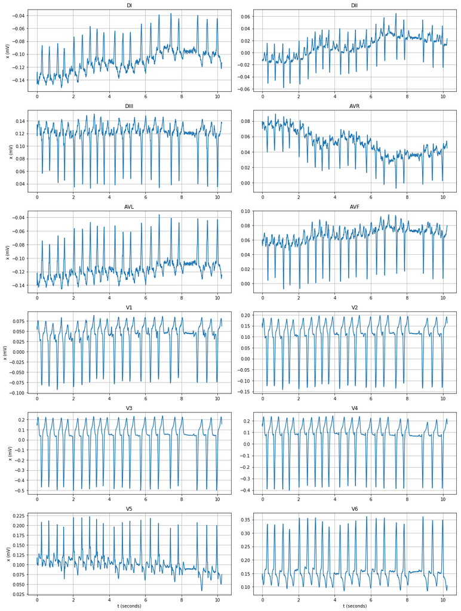

```python
index = 1000 # Change this number to change the sample you pick from the dataset

# Leads names
name = ['DI', 'DII', 'DIII', 'AVR', 'AVL', 'AVF',
        'V1', 'V2', 'V3', 'V4', 'V5', 'V6']
# Sample rate
sample_rate=400

# Plot 12 leads
fig, ax = plt.subplots(nrows=6, ncols=2, figsize=(15, 20))
leads = np.array(ecg_signals)
k = 0
for i in range(6):
    for j in range(2):
        x = leads[index, :, k]
        n = len(x)
        ax[i, j].plot(np.arange(0, 1.0/sample_rate * n, 1.0/sample_rate), x)
        ax[i, j].set_title(name[k])
        ax[i, j].grid()
        if i == 5:
            ax[i, j].set_xlabel('t (seconds)')
        if j == 0:
            ax[i, j].set_ylabel('x (mV)')
        k += 1
fig.tight_layout()
fig
# Uncomment to use plotly instead of matplotlib
# plotly_fig = tls.mpl_to_plotly(fig)
# py.iplot(plotly_fig)
```

### Training and test sets

We split the full dataset in training and test sets.

```python
# Split dataset in train and test
train_test_split = 0.8  # Training dataset size = nentries * train_test_split
                        # Test dataset size = nentries * (1 - train_test_split)
start_train, end_train = 0, int(nentries * 0.8)
start_test, end_test = end_train, nentries

# Training set
X_train = HDF5Matrix("dataset/ecg_classification_v0.1.hdf5",
                     "ecg_signals", start_train, end_train)
Y_train = HDF5Matrix("dataset/ecg_classification_v0.1.hdf5",
                     "diagn", start_train, end_train)

# Test set
X_test = HDF5Matrix("dataset/ecg_classification_v0.1.hdf5",
                    "ecg_signals", start_test, end_test)
Y_test = HDF5Matrix("dataset/ecg_classification_v0.1.hdf5",
                    "diagn", start_test, end_test)
```

## Neural Network Architecture

Next we presented a function that can be used to build unidimensional residual neural networks. The neural network architecture consists of the sequence:

````
```input -> convolutional layer -> n residual blocks -> dense output layer ```
````

Each residual block receives an input with shape `(nsamples_in, nfilters_in)` and returns another `(nsamples_out, nfilters_out)`. The number of samples always decrease (or is mantained) - that is `nsamples_in >= nsamples_out` - and the number of filters usually increase (or is mantained) - that is `nfilters_in <= nfilters_out`. When required we use max pooling to decrease the number of samples in the skip connection and a convolution with kernel of size 1 to modify the number of filters in the skip connection, making the sizes compatibles with the rest of the neural network.

```python
def ResNet1D(input_dims, residual_blocks_dims, nclasses,
             dropout_rate=0.8, kernel_size=16, kernel_initializer='he_normal'):
    """Create unidimensiona residual neural network model.

    Parameters
    ----------
    input_dims : tuple
        Input dimensions. Tuple containing dimensions for the neural network
        input tensor. Should be like: ``(nsamples, nfilters)``.
    residual_blocks_dims : list of tuples
        Dimensions of residual blocks.  The i-th tuple should contain the dimensions
        of the output (i-1)-th residual block and the input to the i-th residual
        block. Each tuple shoud be like: ``(nsamples, nfilters)``.
    nclasses : int
        Number of classes in the output layer.
    dropout_rate: float
        Rate of dropout layers. Between 0 and 1. By default 0.8.
    kernel_size : int
        Kernel length used in convolutional layers. By default 16,
        same as in (Rajpurkar et al., 2017) .
    kernel_initializer : str
        Method used for initializing the kernel By default 'he_normal'
        same as in (Rajpurkar et al., 2017) .

    Returns
    -------
    model: keras.models.Model
        Keras model describing the neural network archtecture

    Notes
    -----
    When specifing ``residual_blocks_dims`` the number of samples
    should always decrease and the ratio between two consecutive
    ``nsamples`` should be an integer number.
    Besides that it is usual in residual networks that the number
    of filters should always increase.

    """
    # TODO: Try to include l2 regularization in the parameters from all layers.
    # This may help reducing variance error of our model.

    # Residual Block
    def residual_block(X, nsamples_in, nsamples_out,
                       nfilters_in, nfilters_out, first_block):
        # Skip Connection
        # Deal with downsampling
        downsample = nsamples_in // nsamples_out
        if downsample > 1:
            Y = MaxPooling1D(downsample, strides=downsample, padding='same')(X)
        elif downsample == 1:
            Y = X
        else:
            raise ValueError("Number of samples should always decrease.")
        # Deal with nfiters dimension increase
        if nfilters_in != nfilters_out:
            # This is one of the two alternatives presented in ResNet paper
            # Other option is to just fill the matrix with zeros.
            # TODO: try the alternative and see which one works better (low priority).
            Y = Conv1D(nfilters_out, 1, padding='same',
                       use_bias=False, kernel_initializer=kernel_initializer)(Y)

        # End of 2nd layer from last residual block
        if not first_block:
            X = BatchNormalization()(X)
            X = Activation('relu')(X)
            X = Dropout(dropout_rate)(X)

        # 1st layer
        X = Conv1D(nfilters_out, kernel_size, padding='same',
                   use_bias=False, kernel_initializer=kernel_initializer)(X)
        X = BatchNormalization()(X)
        X = Activation('relu')(X)
        X = Dropout(dropout_rate)(X)

        # 2nd layer
        X = Conv1D(nfilters_out, kernel_size, strides=downsample, padding='same',
                   use_bias=False, kernel_initializer=kernel_initializer)(X)
        X = Add()([X, Y]) # Skip connection and main connection
        return X

    # Define input representing ecg_signals
    ecg_signals = Input(shape=input_dims, dtype=np.float32, name='ecg_signals')
    X = ecg_signals

    # First layer
    downsample = input_dims[0] // residual_blocks_dims[0][0]
    X = Conv1D(residual_blocks_dims[0][1], kernel_size, strides=downsample,
               padding='same', kernel_initializer=kernel_initializer,
               use_bias=False)(X)
    X = BatchNormalization()(X)
    X = Activation('relu')(X)

    # Residual blocks
    first_block = True
    nresidual_blocks = len(residual_blocks_dims) - 1
    for i in range(nresidual_blocks):
        X = residual_block(X, residual_blocks_dims[i][0], residual_blocks_dims[i+1][0],
                           residual_blocks_dims[i][1], residual_blocks_dims[i+1][1], first_block)
        first_block = False
    # End of 2nd layer from last residual block
    X = BatchNormalization()(X)
    X = Activation('relu')(X)
    X = Dropout(dropout_rate)(X)

    # Last layer
    X = Flatten()(X)
    diagnosis = Dense(nclasses, kernel_initializer=kernel_initializer,
                      activation='softmax', name='diagnosis')(X)

    return Model(ecg_signals, diagnosis)
```

```python
# Define dimensions
nclasses = 7
input_dims = [4096, 12]  # Input dimensions
residual_blocks_dims = [[4096, 64],   # Output of conv layer         / Input of 1st residual blk
                        [4096, 64],   # Output of 1st residual blk / Input of 2st residual blk
                        [2048, 64],   # Output of 2st residual blk / Input of 3st residual blk
                        [2048, 64],   # Output of 3rd residual blk / Input of 4st residual blk
                        [1024, 128],  # Output of 4th residual blk / Input of 5st residual blk
                        [1024, 128],  # Output of 5th residual blk / Input of 6st residual blk
                        [512,  128],  # Output of 6th residual blk / Input of 7st residual blk
                        [512,  128],  # Output of 7th residual blk / Input of 8st residual blk
                        [256,  192],  # Output of 8th residual blk / Input of 9st residual blk
                        [256,  192],  # Output of 9th residual blk / Input of 10st residual blk
                        [128,  192],  # Output of 10th residual blk / Input of 11st residual blk
                        [128,  192],  # Output of 11th residual blk / Input of 12st residual blk
                        [64,   256],  # Output of 12th residual blk / Input of 13st residual blk
                        [64,   256],  # Output of 13th residual blk / Input of 14st residual blk
                        [32,   256],  # Output of 14th residual blk / Input of 15st residual blk
                        [32,   256],  # Output of 15th residual blk / Input of 16st residual blk
                        [16,   256]]  # Output of 16th residual blk / Input of dense layer

# Get model
model = ResNet1D(input_dims, residual_blocks_dims, nclasses)

# Present model summary
model.summary()
```

```
__________________________________________________________________________________________________
Layer (type)                    Output Shape         Param #     Connected to
==================================================================================================
ecg_signals (InputLayer)        (None, 4096, 12)     0
__________________________________________________________________________________________________
conv1d_37 (Conv1D)              (None, 4096, 64)     12288       ecg_signals[0][0]
__________________________________________________________________________________________________
batch_normalization_34 (BatchNo (None, 4096, 64)     256         conv1d_37[0][0]
__________________________________________________________________________________________________
activation_34 (Activation)      (None, 4096, 64)     0           batch_normalization_34[0][0]
__________________________________________________________________________________________________
conv1d_38 (Conv1D)              (None, 4096, 64)     65536       activation_34[0][0]
__________________________________________________________________________________________________
batch_normalization_35 (BatchNo (None, 4096, 64)     256         conv1d_38[0][0]
__________________________________________________________________________________________________
activation_35 (Activation)      (None, 4096, 64)     0           batch_normalization_35[0][0]
__________________________________________________________________________________________________
dropout_33 (Dropout)            (None, 4096, 64)     0           activation_35[0][0]
__________________________________________________________________________________________________
conv1d_39 (Conv1D)              (None, 4096, 64)     65536       dropout_33[0][0]
__________________________________________________________________________________________________
add_17 (Add)                    (None, 4096, 64)     0           conv1d_39[0][0]
                                                                 activation_34[0][0]
__________________________________________________________________________________________________
batch_normalization_36 (BatchNo (None, 4096, 64)     256         add_17[0][0]
__________________________________________________________________________________________________
activation_36 (Activation)      (None, 4096, 64)     0           batch_normalization_36[0][0]
__________________________________________________________________________________________________
dropout_34 (Dropout)            (None, 4096, 64)     0           activation_36[0][0]
__________________________________________________________________________________________________
conv1d_40 (Conv1D)              (None, 4096, 64)     65536       dropout_34[0][0]
__________________________________________________________________________________________________
batch_normalization_37 (BatchNo (None, 4096, 64)     256         conv1d_40[0][0]
__________________________________________________________________________________________________
activation_37 (Activation)      (None, 4096, 64)     0           batch_normalization_37[0][0]
__________________________________________________________________________________________________
dropout_35 (Dropout)            (None, 4096, 64)     0           activation_37[0][0]
__________________________________________________________________________________________________
conv1d_41 (Conv1D)              (None, 2048, 64)     65536       dropout_35[0][0]
__________________________________________________________________________________________________
```

[output cut: 290 more lines]

```
__________________________________________________________________________________________________
batch_normalization_66 (BatchNo (None, 16, 256)      1024        add_32[0][0]
__________________________________________________________________________________________________
activation_66 (Activation)      (None, 16, 256)      0           batch_normalization_66[0][0]
__________________________________________________________________________________________________
dropout_64 (Dropout)            (None, 16, 256)      0           activation_66[0][0]
__________________________________________________________________________________________________
flatten_2 (Flatten)             (None, 4096)         0           dropout_64[0][0]
__________________________________________________________________________________________________
diagnosis (Dense)               (None, 7)            28679       flatten_2[0][0]
==================================================================================================
Total params: 17,250,055
Trainable params: 17,238,919
Non-trainable params: 11,136
__________________________________________________________________________________________________
```

```python
# Display Neural network architecture
# NOTE: require `graphviz` installed on your computer
# On ubuntu/debian run: sudo apt-get install graphviz
# On mac run: follow the instructions on http://macappstore.org/graphviz-2/
SVG(model_to_dot(model, show_layer_names=False,
                 show_shapes=True).create(prog='dot', format='svg'))
```

[figure not shown]

## Training Deep Neural Network

In (Rajpurkar et al., 2017) the neural network is trained using Adam optimizer with default parameters, reducing the learning rate by a factor of 10 whenever the validation loss stops improving. We will adopt a similar strategy for training our neural network.

```python
# Optimization parameters
lr = 0.001  # Learning rate
epochs = 10
batch_size = 64  # In my personal computer I run out
                 # ouf memory whenever I set batch_size >= 256

# Adam optimizer
opt = Adam(lr, beta_1=0.9, beta_2=0.999)

# Compile model
model.compile(loss='categorical_crossentropy',
              optimizer=opt, metrics=['accuracy'])

# TODO: Try more callback options. We could try to use :
# - `EarlyStopping` for regularization.
# - `LearningRateScheduler` for more elaborate strategies
#   of updating the learning rate (instead of ReduceLROnPlateau).
# - and so on...
# Take a look at https://keras.io/callbacks/
callbacks = []

# Reduce learning rate on platteu. That is, we
# reduce the learning rate when the validation
# loss stops improving. This strategy is addopted
# in (Rajpurkar et al., 2017).
callbacks.append(ReduceLROnPlateau(monitor='val_loss', factor=0.1,
                                   patience=10, min_lr=lr/10000))


# Create file for tensorboard visualization.
# Run tensor board from command line to
# visualize dynamic graphs of your training
# and test metrics. Run:
# $ tensorboard --logdir=/full_path_to_your_logs
callbacks.append(TensorBoard(log_dir='./logs',  batch_size=batch_size,
                             write_graph=False))

# Save the model from time to time.
# To load the model just run:
# model = load_model('./backup_model.hdf5')
callbacks.append(ModelCheckpoint('./backup_model.hdf5', period=10))


# Train model
model.fit(X_train, Y_train,
          batch_size=batch_size,
          epochs=epochs,
          validation_data=(X_test, Y_test),
          shuffle='batch', # This option is important because our dataset is an HDF5 file
          callbacks=callbacks)
```